# NYPD_shootings

David Sánchez

2025-07-10

### NYPD Shooting Incident Data (Historic)

List of every shooting incident that occurred in NYC going back to 2006 through the end of 2024. This data was reviewed by the Office of Management Analysis and Planning before being posted on the NYPD website. Each record represents a shooting incident in NYC and includes information about the event, the location and time of occurrence. In addition, information related to suspect and victim demographics is also included.

source: https://catalog.data.gov/dataset/nypd-shooting-incident-data-historic

```r
shootings <- read_csv("https://data.cityofnewyork.us/api/views/833y-fsy8/rows.csv?accessType=DOWNLOAD")
```

Not sure what columns will not be need yet. There is missing data on location and perpetrator details, we shall treat it as unknown.

```r
shootings_tidy <- shootings %>%
  rename(key = INCIDENT_KEY, #standarizing names
         date = OCCUR_DATE,
         time = OCCUR_TIME,
         borough = BORO,
         precinct = PRECINCT,
         jurisdiction = JURISDICTION_CODE,
         loc_class = LOC_CLASSFCTN_DESC,
         loc_desc = LOCATION_DESC,
         ins_out = LOC_OF_OCCUR_DESC,
         murder_flag = STATISTICAL_MURDER_FLAG,
         perp_age = PERP_AGE_GROUP,
         perp_sex = PERP_SEX,
         perp_race = PERP_RACE,
         vic_age = VIC_AGE_GROUP,
         vic_sex = VIC_SEX,
         vic_race = VIC_RACE,
         x_coord = X_COORD_CD,
         y_coord = Y_COORD_CD,
         lat = Latitude,
         long = Longitude,
         long_lat = Lon_Lat) %>%
  mutate(perp_age = na_if(perp_age, "UNKNOWN"), #cleaning missing
         perp_age = na_if(perp_age, "(null)"),
         perp_age = na_if(perp_age, "1020"),
         perp_age = na_if(perp_age, "1028"),
         perp_age = na_if(perp_age, "2021"),
         perp_age = na_if(perp_age, "224"),
         perp_age = na_if(perp_age, "940"),
         perp_sex = na_if(perp_sex, "(null)"),
         perp_race = na_if(perp_race, "(null)"),
         perp_race = na_if(perp_race, "UNKNOWN"),
         vic_age = na_if(vic_age, "UNKNOWN"),
         vic_age = na_if(vic_age, "1022"),
         vic_race = na_if(vic_race, "UNKNOWN"),
         loc_class = na_if(loc_class, "(null)"),
         #loc_clas = fct_recode(loc_class, "(Other)" = "OTHER"),
         date = mdy(date), #classyfing data
         borough = as.factor(borough),
         ins_out = as.factor(ins_out),
         precinct = as.factor(precinct),
         jurisdiction = as.factor(jurisdiction),
         loc_class = as.factor(loc_class),
         perp_sex = as.factor(perp_sex),
         perp_race = as.factor(perp_race),
         perp_age = as.factor(perp_age),
         vic_age = as.factor(vic_age),
         vic_sex = as.factor(vic_sex),
         vic_race = as.factor(vic_race))

shootings_tidy <- shootings_tidy %>%
  mutate(vic_age = factor(vic_age, levels = levels(shootings_tidy$vic_age), ordered = T),
         perp_age = factor(perp_age, levels = levels(shootings_tidy$perp_age), ordered = T))

summary(shootings_tidy)
```

```
##       key                 date                time
##  Min.   :  9953245   Min.   :2006-01-01   Length:29744
##  1st Qu.: 67321140   1st Qu.:2009-10-29   Class1:hms
##  Median :109291972   Median :2014-03-25   Class2:difftime
##  Mean   :133850951   Mean   :2014-10-31   Mode  :numeric
##  3rd Qu.:214741917   3rd Qu.:2020-06-29
##  Max.   :299462478   Max.   :2024-12-31
##
##           borough         ins_out         precinct     jurisdiction
##  BRONX        : 8834   INSIDE :  682   75     : 1680   0   :24957
##  BROOKLYN     :11685   OUTSIDE: 3466   73     : 1561   1   :  109
##  MANHATTAN    : 3977   NA's   :25596   67     : 1288   2   : 4676
##  QUEENS       : 4426                   44     : 1159   NA's:    2
##  STATEN ISLAND:  822                   79     : 1073
##                                        47     : 1048
##                                        (Other):21935
##       loc_class       loc_desc         murder_flag      perp_age
##  STREET    : 2639   Length:29744       Mode :logical   <18  : 1805
##  HOUSING   :  643   Class :character   FALSE:23979     18-24: 6630
##  DWELLING  :  341   Mode  :character   TRUE :5765      25-44: 6342
##  COMMERCIAL:  276                                      45-64:  775
##  OTHER     :   74                                      65+  :   67
##  (Other)   :  168                                      NA's :14125
##  NA's      :25603
##  perp_sex                              perp_race      vic_age      vic_sex
##  F   :  461   AMERICAN INDIAN/ALASKAN NATIVE:    2   <18  : 3081   F: 2891
##  M   :16845   ASIAN / PACIFIC ISLANDER      :  184   18-24:10677   M:26841
##  U   : 1500   BLACK                         :12323   25-44:13563   U:   12
##  NA's:10938   BLACK HISPANIC                : 1487   45-64: 2118
##               WHITE                         :  305   65+  :  236
##               WHITE HISPANIC                : 2667   NA's :   69
##               NA's                          :12776
##                            vic_race        x_coord           y_coord
##  AMERICAN INDIAN/ALASKAN NATIVE:   13   Min.   : 914928   Min.   :125757
##  ASIAN / PACIFIC ISLANDER      :  478   1st Qu.:1000094   1st Qu.:183042
##  BLACK                         :20999   Median :1007826   Median :195506
##  BLACK HISPANIC                : 2930   Mean   :1009442   Mean   :208722
##  WHITE                         :  741   3rd Qu.:1016739   3rd Qu.:239980
##  WHITE HISPANIC                : 4511   Max.   :1066815   Max.   :271128
##  NA's                          :   72
##       lat             long          long_lat
##  Min.   :40.51   Min.   :-74.25   Length:29744
##  1st Qu.:40.67   1st Qu.:-73.94   Class :character
##  Median :40.70   Median :-73.91   Mode  :character
##  Mean   :40.74   Mean   :-73.91
##  3rd Qu.:40.83   3rd Qu.:-73.88
##  Max.   :40.91   Max.   :-73.70
##  NA's   :97      NA's   :97
```

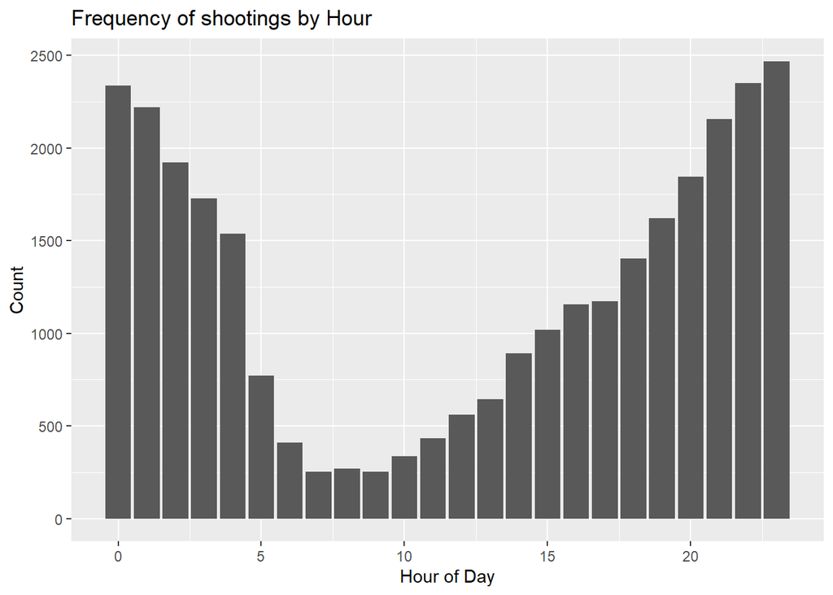

```r
shootings_tidy %>%
  mutate(hour = hour(shootings_tidy$time)) %>%
ggplot(aes(x = hour)) +
  geom_bar() +
  labs(title = "Frequency of shootings by Hour", x = "Hour of Day", y = "Count")
```

**Analysis:**

This graph shows that shootings occur mostly at night. This is probably a mixture of daytime being mostly comprised of regular working hours and perpetrators preferring the stealth provided by the cover of night.

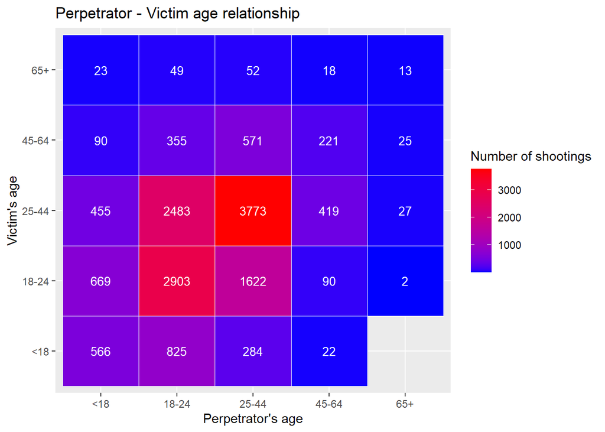

```r
shootings_tidy %>%
  filter(!is.na(perp_age)) %>%    # Remove NA perpetrator ages
  filter(!is.na(vic_age)) %>%
  count(perp_age, vic_age) %>% #this is n
  ggplot(aes(x = perp_age, y = vic_age, fill = n)) +
  geom_tile(color = "white") +
  geom_text(aes(label = n), color = "white", size = 3.5) +
  scale_fill_gradient(low = "blue", high = "red") +
  labs(title = "Perpetrator - Victim age relationship",
       x = "Perpetrator's age",
       y = "Victim's age",
       fill = "Number of shootings")
```

**Analysis:**

This heat map shows that shootings happen mainly between people of the same age. Chances of being involved in one grow with age and then drop dramatically after 44, this probably hints to the drop off actually being earlier so we would be able to extract a more accurate assessment if we got our hands on data with smaller age ranges.

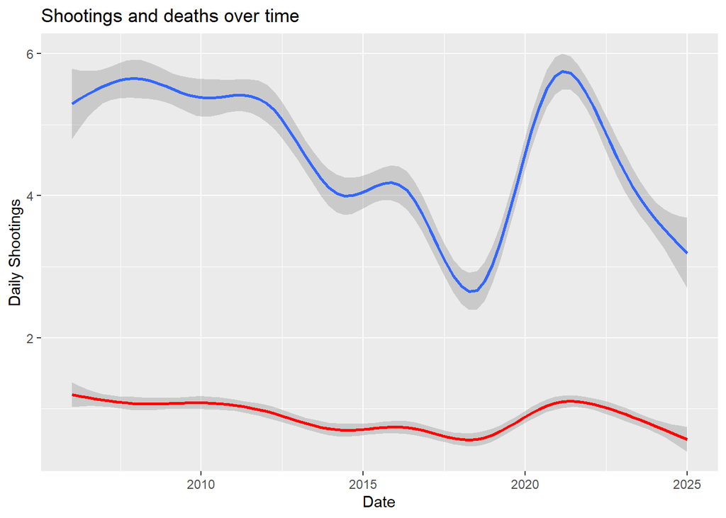

```r
shootings_tidy %>%
  group_by(date) %>%
  summarise(num_shootings = n(), num_deaths = sum(murder_flag)) %>%
ggplot() +
  geom_smooth(aes(x = date, y = num_shootings)) +
  geom_smooth(aes(x = date, y = num_deaths), color = "red") +
  labs(title = "Shootings and deaths over time",
       x = "Date",
       y = "Daily Shootings")
```

```r
  labs(title = "Amount of shootings per day", x = "Hour of Day", y = "Count")
```

```
## $x
## [1] "Hour of Day"
##
## $y
## [1] "Count"
##
## $title
## [1] "Amount of shootings per day"
##
## attr(,"class")
## [1] "labels"
```

**Analysis:**

This visualization choose the general shooting trends throughout the historic data, interestingly violence seems to have spiked during covid, but seems to be normalizing and on a downward trend in general.

```r
shootings_model <- shootings_tidy %>%
  mutate(fatal = as.numeric(murder_flag == T),
         loc_class = relevel(loc_class, ref = "STREET")) %>% #making street the reference since its the most common
  filter(!is.na(fatal))

mod <- glm(fatal ~ loc_class, family = binomial(link = "logit"), data = shootings_model)
summary(mod)
```

```
##
## Call:
## glm(formula = fatal ~ loc_class, family = binomial(link = "logit"),
##     data = shootings_model)
##
## Coefficients:
##                      Estimate Std. Error z value Pr(>|z|)
## (Intercept)           -1.4935     0.0503 -29.691  < 2e-16 ***
## loc_classCOMMERCIAL    0.3558     0.1491   2.386  0.01704 *
## loc_classDWELLING      0.8956     0.1239   7.231 4.79e-13 ***
## loc_classHOUSING      -0.2224     0.1207  -1.842  0.06545 .
## loc_classOTHER        -0.7653     0.4003  -1.912  0.05591 .
## loc_classPARKING LOT  -0.4525     0.7576  -0.597  0.55036
## loc_classPLAYGROUND    0.5667     0.2757   2.056  0.03981 *
## loc_classTRANSIT       0.9414     0.2923   3.220  0.00128 **
## loc_classVEHICLE       1.6758     0.3532   4.745 2.09e-06 ***
## ---
## Signif. codes:  0 '***' 0.001 '**' 0.01 '*' 0.05 '.' 0.1 ' ' 1
##
## (Dispersion parameter for binomial family taken to be 1)
##
##     Null deviance: 4163.1  on 4140  degrees of freedom
## Residual deviance: 4065.5  on 4132  degrees of freedom
##   (25603 observations deleted due to missingness)
## AIC: 4083.5
##
## Number of Fisher Scoring iterations: 4
```

**Analysis:**

This model compares the lethality of the most commons shooting (those in the street) with other location, we can see the most relevant results in vehicles, were shootings are much more deadly, and no indicates to be safer than the baseline.

### Conclusion

I specifically didn’t attempt analysis with the race variables because of knowing that it could be affected by bias, from me as an analyst because I do not live on NY or the US for that matter and I’m not fully aware of all the missing factors that could explain the results in a more complete way, like the demographics of each district. There could also be bias from the data gathering method, in this case the NYPD, since the density of patrols in a certain area would increase the amount of reports filled.

On the age relationship visualization I excluded the NA’s result. I can make an educated guess though that these originate mostly from perpetrators that weren’t caught, and extrapolating they are statisticaly in a similar age range as the victim based on the result, but without further information that could be a biased conclusion.